# Testing Assumptions 6-5-20

Maura O’Fallon

6/5/2020

# Libraries and theme for ggplot2

Enable tidyverse

Set theme for ggplot2

```r
library(tidyverse)
maura.theme <- theme_bw() + theme(axis.line = element_line(colour = "gray29"), panel.grid.minor = element_blank(),
    panel.grid.major = element_blank(), panel.border = element_blank(), panel.background = element_blank(),
    legend.title = element_blank())  #custom graphics theme for ggplot2
```

# Read in and examine the data

The file is called Assign1.csv, and there is a header row. Examine the structure of the data (str) and print out the first 15 rows (head). This is in wide form.

```r
SpellTest <- read.csv("/Users/mauraofallon/Documents/R WERK/multivariable work group summer 2020/Assign1.csv",
    header = T)
str(SpellTest)
```

```
## 'data.frame':    750 obs. of  3 variables:
##  $ ID   : int  1 2 3 4 5 6 7 8 9 10 ...
##  $ Phila: num  89.1 83.5 88.6 89.1 89.6 ...
##  $ Pitt : num  58.5 61.2 51.1 81.3 35.8 ...
```

```r
head(SpellTest, n = 15)
```

```
##    ID    Phila     Pitt
## 1   1 89.06328 58.47289
## 2   2 83.48570 61.23845
## 3   3 88.60671 51.10596
## 4   4 89.07623 81.31154
## 5   5 89.59111 35.84061
## 6   6 98.06121 60.79069
## 7   7 87.69030 77.18116
## 8   8 82.11975 61.88444
## 9   9 92.48217 86.76136
## 10 10 89.44023 77.62240
## 11 11 88.97827 52.01393
## 12 12 93.17784 64.10183
## 13 13 75.46663 65.17297
## 14 14 87.23171 69.03667
## 15 15 89.23274 57.07759
```

# Convert the data from wide form to long form

Generate a new dataframe by “melting” the original. Name the new variables “city” and “spelling test score”. Print the first five rows of the new dataframe

First, must activate the reshape2 package

```r
library(reshape2)
SpellTestLong <- melt(SpellTest, id = c("ID"), measured = c("Phila", "Pitt"), variable.name = "city",
    value.name = "spelling test score")
head(SpellTestLong, n = 5)
```

```
##   ID  city spelling test score
## 1  1 Phila            89.06328
## 2  2 Phila            83.48570
## 3  3 Phila            88.60671
## 4  4 Phila            89.07623
## 5  5 Phila            89.59111
```

# Generate descriptive statistics by each city (use describeBy)

Must activate psych package

```r
library(psych)
describeBy(SpellTestLong$`spelling test score`, group = SpellTestLong$city)
```

```
##
##  Descriptive statistics by group
## group: Phila
##    vars   n  mean   sd median trimmed  mad   min    max range  skew kurtosis
## X1    1 750 90.04 4.78  90.16   90.08 4.69 75.35 104.67 29.32 -0.12     0.09
##      se
## X1 0.17
## ------------------------------------------------------------
## group: Pitt
##    vars   n  mean    sd median trimmed   mad   min    max range  skew kurtosis
## X1    1 750 65.19 15.68  65.17   65.26 15.25 18.18 112.52 94.34 -0.03    -0.18
##      se
## X1 0.57
```

# Generate histograms for Philadelphia and Pittsburgh

Must activate ggplot2 package

```r
library(ggplot2)
by(data = SpellTestLong, INDICES = SpellTestLong$city, FUN = describe)  #generate descriptive stats w different function
```

```
## SpellTestLong$city: Phila
##                     vars   n   mean     sd median trimmed    mad   min    max
## ID                     1 750 375.50 216.65 375.50  375.50 277.99  1.00 750.00
## city*                  2 750   1.00   0.00   1.00    1.00   0.00  1.00   1.00
## spelling test score    3 750  90.04   4.78  90.16   90.08   4.69 75.35 104.67
##                      range  skew kurtosis   se
## ID                  749.00  0.00    -1.20 7.91
## city*                 0.00   NaN      NaN 0.00
## spelling test score  29.32 -0.12     0.09 0.17
## ------------------------------------------------------------
## SpellTestLong$city: Pitt
##                     vars   n   mean     sd median trimmed    mad   min    max
## ID                     1 750 375.50 216.65 375.50  375.50 277.99  1.00 750.00
## city*                  2 750   2.00   0.00   2.00    2.00   0.00  2.00   2.00
## spelling test score    3 750  65.19  15.68  65.17   65.26  15.25 18.18 112.52
##                      range  skew kurtosis   se
## ID                  749.00  0.00    -1.20 7.91
## city*                 0.00   NaN      NaN 0.00
## spelling test score  94.34 -0.03    -0.18 0.57
```

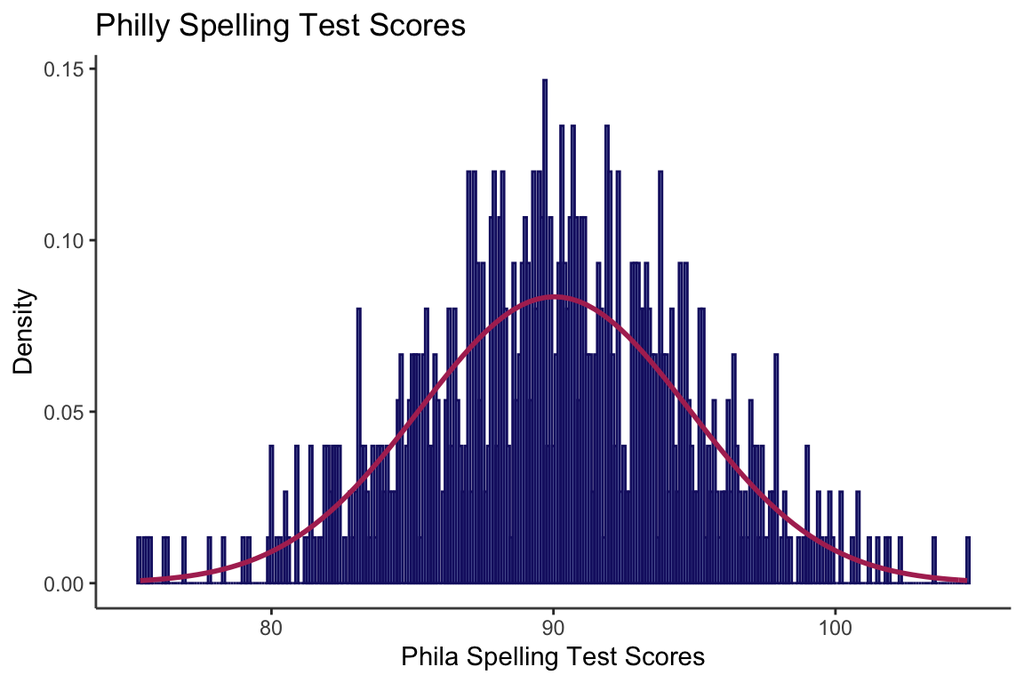

```r
PhillyData <- subset(SpellTestLong, SpellTestLong$city == "Phila")  #creating a PHILLY subset of melted dataset
PittData <- subset(SpellTestLong, SpellTestLong$city == "Pitt")  #creating a Pitt subset of melted dataset

# next, will insert ugly code to make pretty philly histo
PhillyHisto <- ggplot(PhillyData, aes(PhillyData$`spelling test score`)) + geom_histogram(aes(y = ..density..),
    colour = "midnightblue", fill = "lightsteelblue1", binwidth = 0.1) + xlab("Phila Spelling Test Scores") +
    ylab("Density") + maura.theme + ggtitle("Philly Spelling Test Scores") + stat_function(fun = dnorm,
    args = list(mean = mean(SpellTest$Phila), sd = sd(SpellTest$Phila)), color = "maroon",
    size = 1)
PhillyHisto  #tells R to print Philly histo
```

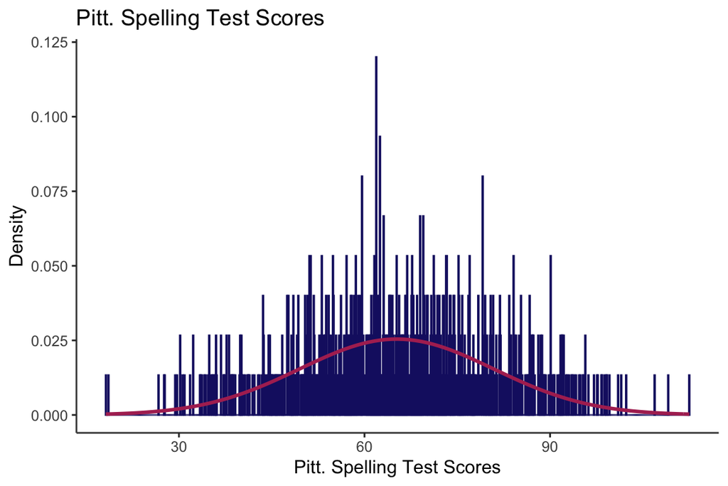

```r
# next, more ugly code for pretty Pitt histo
PittHisto <- ggplot(PittData, aes(PittData$`spelling test score`)) + geom_histogram(aes(y = ..density..),
    colour = "midnightblue", fill = "lightsteelblue1", binwidth = 0.1) + xlab("Pitt. Spelling Test Scores") +
    ylab("Density") + maura.theme + ggtitle("Pitt. Spelling Test Scores") + stat_function(fun = dnorm,
    args = list(mean = mean(SpellTest$Pitt), sd = sd(SpellTest$Pitt)), color = "maroon",
    size = 1)
PittHisto  #tells R to print Pitt histo
```

# Run tests of normality on Pitt and Phila (Shapiro Wilk)

Getting a significant p value means the dist is NOT normal (null hypo is normal dist)

```r
normtest.Phila <- shapiro.test(PhillyData$`spelling test score`)  #we are still using the subset of data created earlier
normtest.Phila  #NS
```

```
##
##  Shapiro-Wilk normality test
##
## data:  PhillyData$`spelling test score`
## W = 0.99788, p-value = 0.4718
```

```r
normtest.Pitt <- shapiro.test(PittData$`spelling test score`)  #we are still using the subset of data created earlier
normtest.Pitt  #NS
```

```
##
##  Shapiro-Wilk normality test
##
## data:  PittData$`spelling test score`
## W = 0.99831, p-value = 0.6871
```

Shapiro-Wilk tests for both cities yielded nonsignificant p-values. We will fail to reject null hypothesis of normality for spelling test scores in both Philly and Pitt.

# Generate boxplots of the cities

Red box plot - Philly scores // Blue box plot - Pitt scores

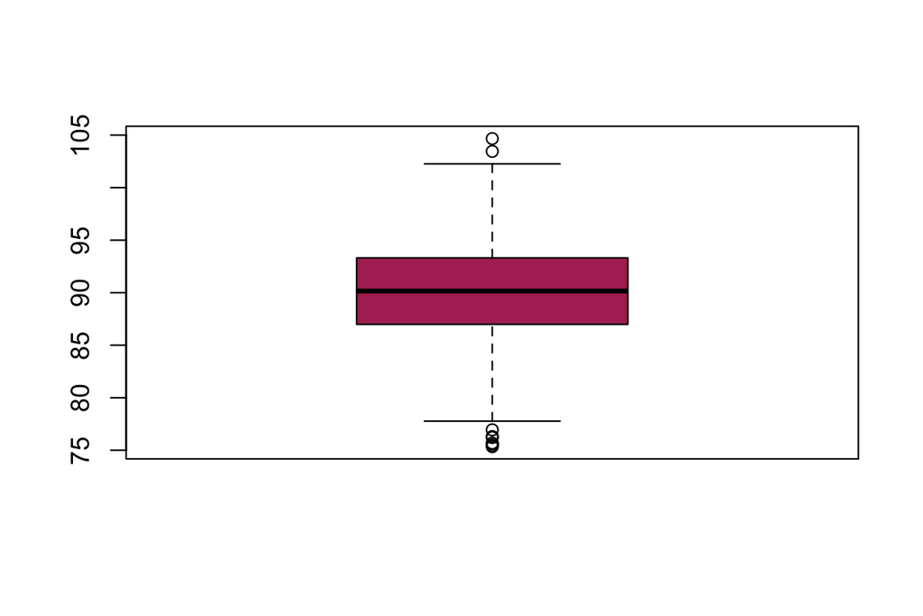

```r
boxplot.Phila <- boxplot(PhillyData$`spelling test score`, col = "maroon")  #we are still using the subset of data created earlier
```

```r
boxplot.Phila
```

```
## $stats
##           [,1]
## [1,]  77.76653
## [2,]  86.98396
## [3,]  90.15578
## [4,]  93.31328
## [5,] 102.26032
##
## $n
## [1] 750
##
## $conf
##          [,1]
## [1,] 89.79062
## [2,] 90.52094
##
## $out
## [1]  75.46663  75.62979  76.21475  76.30123  75.34759  76.94478  75.67791
## [8] 103.45454 104.66887
##
## $group
## [1] 1 1 1 1 1 1 1 1 1
##
## $names
## [1] "1"
```

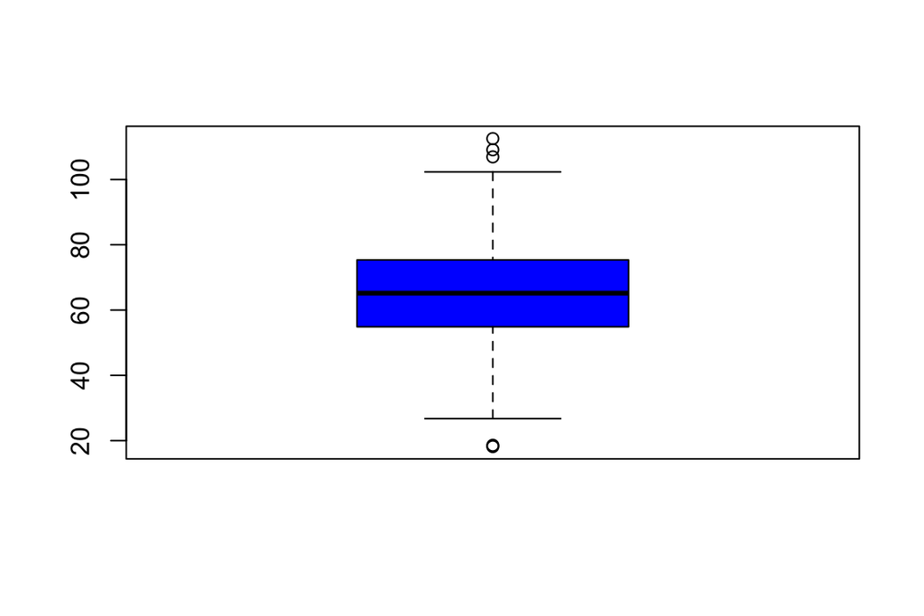

```r
boxplot.Pitt <- boxplot(PittData$`spelling test score`, col = "blue")  #we are still using the subset of data we created earlier
```

```r
boxplot.Pitt
```

```
## $stats
##           [,1]
## [1,]  26.74978
## [2,]  54.86819
## [3,]  65.17070
## [4,]  75.34686
## [5,] 102.30992
##
## $n
## [1] 750
##
## $conf
##          [,1]
## [1,] 63.98921
## [2,] 66.35218
##
## $out
## [1]  18.17616 112.51906 106.92037  18.58017 109.09732
##
## $group
## [1] 1 1 1 1 1
##
## $names
## [1] "1"
```

# Examine variance differences between cities (Levene Test)

Levene test - uses this to evaluate homogeneity of variances assumption. Null hypothesis is that variances are equal (i.e., differences between variances is zero). Nonsignificant p-values mean that variances are roughly = and assumption has not been violated.

Must activate car package first.

```r
library(car)
levene.spell <- leveneTest(SpellTestLong$`spelling test score`, SpellTestLong$city,
    center = mean)
levene.spell  #highly significant! p<2.2e-16
```

```
## Levene's Test for Homogeneity of Variance (center = mean)
##         Df F value    Pr(>F)
## group    1  579.59 < 2.2e-16 ***
##       1498
## ---
## Signif. codes:  0 '***' 0.001 '**' 0.01 '*' 0.05 '.' 0.1 ' ' 1
```

Highly significant p value. We reject null hypo that variances are equal. We can’t really assume equal variance for these data.

# Run a t.test comparing Phila to Pitt, add an effect size (cohen d). Don’t assume equal variance

Must activate effsize package

```r
IndTtest <- t.test(SpellTestLong$`spelling test score` ~ SpellTestLong$city, data = SpellTestLong)
IndTtest  # t=41.504, p< 2.2e-16, highly significant // Philly test scores higher than Pitt scores
```

```
##
##  Welch Two Sample t-test
##
## data:  SpellTestLong$`spelling test score` by SpellTestLong$city
## t = 41.504, df = 886.82, p-value < 2.2e-16
## alternative hypothesis: true difference in means is not equal to 0
## 95 percent confidence interval:
##  23.66989 26.01961
## sample estimates:
## mean in group Phila  mean in group Pitt
##            90.03534            65.19059
```

```r
library(effsize)  #activate effsize package
CohenDSpelling <- cohen.d(SpellTestLong$`spelling test score`, SpellTestLong$city,
    pooled = TRUE, paired = FALSE, na.rm = FALSE, mu = 0, hedges.correction = FALSE,
    conf.level = 0.95, noncentral = FALSE, within = FALSE)
CohenDSpelling  #large effect size!
```

```
##
## Cohen's d
##
## d estimate: 2.143253 (large)
## 95 percent confidence interval:
##    lower    upper
## 2.016162 2.270343
```

# Summarize your finding

To compare spelling test scores between students at Temple and Pitt, an independent sample t-test was completed. Test results indicated a highly significant difference in test scores (t(886.82)= 41.504, p<2.2e-16, d=2.14), such that students from Temple (M=90.04, SD=4.78) achieved higher scores than students from Pitt (M=65.19, SD=15.68). The data do not support Dr. Dickey’s hypothesis.